# WGCNA

Rafael L. B. Coan

27/09/2021

# 1 Introduction

This is WGCNA analysis with step-by-step network construction, as oposed to 17.wgcna_vsd.Rmd, which is one-step network construction.

https://horvath.genetics.ucla.edu/html/CoexpressionNetwork/Rpackages/WGCNA/Tutorials/FemaleLiver-02-networkConstr-man.pdf

```r
library("WGCNA")
```

```r
library("ggplot2")
library("dplyr")
```

# 2 Methods

## 2.1 Load data

Load normalized data from previous notebooks (VST transformation).

```r
options(stringsAsFactors = FALSE)
data <- read.csv("vsdAnnot_11.brohl_normalization.csv", row.names = 1)
```

## 2.2 Transpose matrix and clean data

WGCNA works with a transposed matrix. Now we use the name `datExpr0` because outliers will be removed latter.

```r
# Transpose and clean
datExpr0 = as.data.frame(t(data[, -c(27:29)]))

gsg = goodSamplesGenes(datExpr0, verbose = 3)
```

```
##  Flagging genes and samples with too many missing values...
##   ..step 1
```

```r
gsg$allOK
```

```
## [1] TRUE
```

```r
if (!gsg$allOK) {
# Optionally, print the gene and sample names that were removed:
if (sum(!gsg$goodGenes)>0)
printFlush(paste("Removing genes:", paste(names(datExpr0)[!gsg$goodGenes], collapse = ", ")));
if (sum(!gsg$goodSamples)>0)
printFlush(paste("Removing samples:", paste(rownames(datExpr0)[!gsg$goodSamples], collapse = ", ")));
# Remove the offending genes and samples from the data:
datExpr0 = datExpr0[gsg$goodSamples, gsg$goodGenes]
}
```

## 2.3 Cluster samples

Now we can cluster (based on Eucledian distances) the samples to check for outliers.

```r
sampleTree = hclust(dist(datExpr0), method = "average")
sizeGrWindow(12,9)
par(cex = 0.6)
par(mar = c(0,4,2,0))
plot(sampleTree, main = "Sample clustering to detect outliers", sub="", xlab="", cex.lab = 1.5,cex.axis = 1.5, cex.main = 2)
```

[output not shown]

And we can automatically remove the outliers based on distances.

```r
cutoff <- 250

clust = cutreeStatic(sampleTree, cutHeight = cutoff, minSize = 10)

# Repeat graph with cutoff
sizeGrWindow(12,9)
par(cex = 0.6)
par(mar = c(0,4,2,0))
plot(sampleTree, main = "Sample clustering with cutoff", sub="", xlab="", cex.lab = 1.5, cex.axis = 1.5, cex.main = 2)
abline(h = cutoff, col = "red")

keepSamples = (clust==1)
datExpr = datExpr0[keepSamples, ]
nGenes = ncol(datExpr)
nSamples = nrow(datExpr)

sampleTree2 = hclust(dist(datExpr), method = "average")
sizeGrWindow(12,9)
par(cex = 0.6)
par(mar = c(0,4,2,0))
plot(sampleTree2, main = "Sample clustering dendogram", sub="", xlab="", cex.lab = 1.5, cex.axis = 1.5, cex.main = 2)
```

[output not shown]

## 2.4 Trait data

```r
traitData = read.csv("samples_brohl_pheno.csv")
dim(traitData)
```

```
## [1] 26 13
```

```r
names(traitData)
```

```
##  [1] "Run"         "LibraryName" "SampleName"  "Tissue"      "Sex"
##  [6] "Age"         "Type"        "FusionGene"  "STAG2"       "CDKN2A"
## [11] "TP53"        "BRCA2"       "Location"
```

```r
# Keep columns that we want
allTraits = traitData[, -c(2:4, 8)]
dim(allTraits)
```

```
## [1] 26  9
```

```r
names(allTraits)
```

```
## [1] "Run"      "Sex"      "Age"      "Type"     "STAG2"    "CDKN2A"   "TP53"
## [8] "BRCA2"    "Location"
```

```r
# Match traits with expression matrix
brohlSamples = rownames(datExpr)
traitRows = match(brohlSamples, allTraits$Run)
datTraits = allTraits[traitRows, -1]
rownames(datTraits) = allTraits[traitRows, 1]
```

Relation between traits and expression.

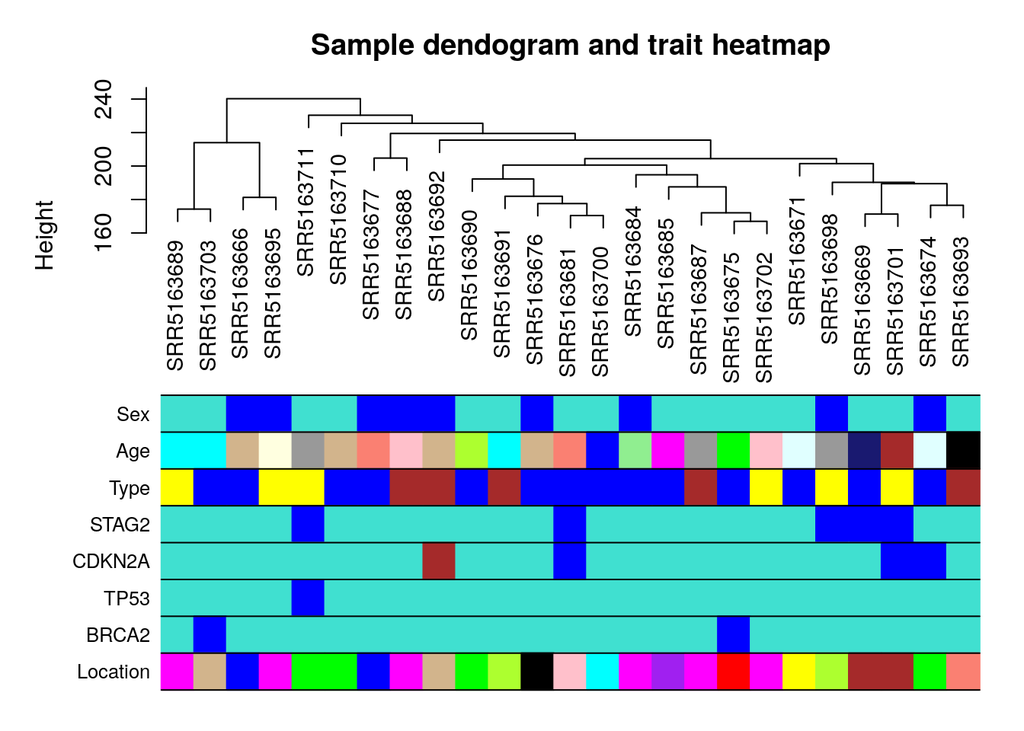

```r
traitColors = labels2colors(datTraits, naColor = "grey")

plotDendroAndColors(sampleTree2, traitColors, groupLabels = names(datTraits), main = "Sample dendogram and trait heatmap")
```

## 2.5 Soft soft-thresholding power

On WGCNA FAQ, they provide “sane defaults” to power value.

| Number of samples | Unsigned and signed hybrid networks | Signed networks |
| --- | --- | --- |
| Less than 20 | 9 | 18 |
| 20-30 | 8 | 16 |
| 30-40 | 7 | 14 |
| more than 40 | 6 | 12 |

Let’s calculate.

```r
powers = c(c(1:10), seq(from = 12, to=20, by=2))

sft = pickSoftThreshold(datExpr, powerVector = powers, verbose = 5)
```

```
## pickSoftThreshold: will use block size 1779.
##  pickSoftThreshold: calculating connectivity for given powers...
##    ..working on genes 1 through 1779 of 25148
```

```
##    ..working on genes 1780 through 3558 of 25148
##    ..working on genes 3559 through 5337 of 25148
##    ..working on genes 5338 through 7116 of 25148
##    ..working on genes 7117 through 8895 of 25148
##    ..working on genes 8896 through 10674 of 25148
##    ..working on genes 10675 through 12453 of 25148
##    ..working on genes 12454 through 14232 of 25148
##    ..working on genes 14233 through 16011 of 25148
##    ..working on genes 16012 through 17790 of 25148
##    ..working on genes 17791 through 19569 of 25148
##    ..working on genes 19570 through 21348 of 25148
##    ..working on genes 21349 through 23127 of 25148
##    ..working on genes 23128 through 24906 of 25148
##    ..working on genes 24907 through 25148 of 25148
##    Power SFT.R.sq  slope truncated.R.sq  mean.k. median.k. max.k.
## 1      1   0.0126 -0.563          0.958 5290.000  5290.000 7630.0
## 2      2   0.3060 -1.790          0.968 1700.000  1660.000 3390.0
## 3      3   0.5400 -2.110          0.978  680.000   636.000 1800.0
## 4      4   0.6580 -2.280          0.976  313.000   276.000 1070.0
## 5      5   0.7210 -2.370          0.971  159.000   131.000  681.0
## 6      6   0.7490 -2.400          0.963   87.500    66.100  459.0
## 7      7   0.7830 -2.340          0.963   51.200    35.500  323.0
## 8      8   0.8090 -2.230          0.956   31.600    19.900  235.0
## 9      9   0.8760 -2.050          0.972   20.400    11.600  176.0
## 10    10   0.9310 -1.970          0.996   13.700     6.920  143.0
## 11    12   0.9490 -2.010          0.994    6.780     2.690  115.0
## 12    14   0.9670 -1.930          0.986    3.730     1.150   96.8
## 13    16   0.9700 -1.830          0.975    2.240     0.534   83.9
## 14    18   0.9720 -1.730          0.968    1.440     0.262   74.1
## 15    20   0.9770 -1.640          0.971    0.981     0.134   66.4
```

```r
# Plot values
sizeGrWindow(9, 5)
par(mfrow = c(1,2))
cex1 = 0.9

# Scale-free topology fit index as a function of the soft-thresholding power
plot(sft$fitIndices[,1], -sign(sft$fitIndices[,3])*sft$fitIndices[,2],xlab="Soft Threshold (power)",
     ylab="Scale Free Topology Model Fit,signed R^2",type="n",main = paste("Scale independence"))
text(sft$fitIndices[,1], -sign(sft$fitIndices[,3])*sft$fitIndices[,2],labels=powers,cex=cex1,col="red")
# this line corresponds to using an R^2 cut-off of h
abline(h=0.80,col="red")

# Mean connectivity as a function of the soft-thresholding power
plot(sft$fitIndices[,1], sft$fitIndices[,5],xlab="Soft Threshold (power)",
     ylab="Mean Connectivity", type="n",main = paste("Mean connectivity"))
text(sft$fitIndices[,1], sft$fitIndices[,5], labels=powers, cex=cex1,col="red")

#write.csv(sft, file = "sft.csv")
```

[output not shown]

We can look at log10(p(k)) vs log10(k) plots to check our scale-free topology, R² and truncated R².

```r
sf <- function(expData, p) {
  k = softConnectivity(expData, power = p)
  sizeGrWindow(10,5)
  par(mfrow=c(1,2))
  hist(k)
  scaleFreePlot(k, main=paste("Check scale free topology for ", p, "\n"))
}

softPower = 9
#sf(datExpr, 8)
sf(datExpr, softPower)
```

[output not shown]

```
##  softConnectivity: FYI: connecitivty of genes with less than 9 valid samples will be returned as NA.
##  ..calculating connectivities..
```

```
##   scaleFreeRsquared slope
## 1              0.86 -2.05
```

```r
#knitr::knit_exit()
```

We choose soft-thresholding of 9. We are starting the analysis with softPower of 9 (different from previous 8), so we can expect **less** connections between nodes and k smaller than before. We can change this value latter to get more results, if necessary.

## 2.6 Step-by-step network construction

Construction of co-expression network.

First step is to calculate co-expression adjacency matrix and TOM similarity and disimilarity.

```r
# Adjacency
adjacency = adjacency(datExpr, power = softPower)

# TOM (topological overlap matrix)
TOM = TOMsimilarity(adjacency);
```

```
## ..connectivity..
## ..matrix multiplication (system BLAS)..
## ..normalization..
## ..done.
```

```r
dissTOM = 1-TOM
```

Now we can cluster our network into modules.

```r
# Clustering with TOM
geneTree = hclust(as.dist(dissTOM), method = "average");
# Plot the resulting clustering tree (dendrogram)
sizeGrWindow(12,9)
plot(geneTree, xlab="", sub="", main = "Gene clustering on TOM-based dissimilarity", labels = FALSE, hang = 0.04)

# We like large modules, so we set the minimum module size relatively high:
minModuleSize = 30;
# Module identification using dynamic tree cut:
dynamicMods = cutreeDynamic(dendro = geneTree, distM = dissTOM,
deepSplit = 2, pamRespectsDendro = FALSE,
minClusterSize = minModuleSize);
```

[output not shown]

```
##  ..cutHeight not given, setting it to 0.999  ===>  99% of the (truncated) height range in dendro.
##  ..done.
```

```r
table(dynamicMods)
```

```
## dynamicMods
##    0    1    2    3    4    5    6    7    8    9   10   11   12   13   14   15
##  606 2328 1574 1483 1424 1350 1252 1159 1090 1090  793  749  543  474  472  462
##   16   17   18   19   20   21   22   23   24   25   26   27   28   29   30   31
##  460  401  395  362  355  347  343  341  327  327  293  278  277  257  245  215
##   32   33   34   35   36   37   38   39   40   41   42   43   44   45   46   47
##  210  209  196  181  178  176  163  162  151  149  148  148  146  126  124  116
##   48   49   50   51   52   53
##  101   92   90   83   76   51
```

```r
# Convert numeric lables into colors
dynamicColors = labels2colors(dynamicMods)
table(dynamicColors)
```

```
## dynamicColors
##         bisque4           black            blue           brown          brown4
##             116            1159            1574            1483             124
##            cyan       darkgreen        darkgrey     darkmagenta  darkolivegreen
##             472             343             327             196             209
##      darkorange     darkorange2         darkred   darkslateblue   darkturquoise
##             293             126             347             101             341
##     floralwhite           green     greenyellow            grey          grey60
##             146            1350             749             606             401
##           ivory       lightcyan      lightcyan1      lightgreen lightsteelblue1
##             148             460             148             395             149
##     lightyellow         magenta   mediumpurple3    midnightblue          orange
##             362            1090             151             462             327
##      orangered4   paleturquoise  palevioletred3            pink           plum1
##             162             215              51            1090             163
##           plum2          purple             red       royalblue     saddlebrown
##              92             793            1252             355             257
##          salmon         salmon4         sienna3         skyblue        skyblue3
##             474              76             181             277             176
##       steelblue             tan        thistle1        thistle2       turquoise
##             245             543              83              90            2328
##          violet           white          yellow     yellowgreen
##             210             278            1424             178
```

```r
# Plot the dendrogram and colors underneath
sizeGrWindow(8,6)
plotDendroAndColors(geneTree, dynamicColors, "Dynamic Tree Cut", dendroLabels = FALSE, hang = 0.03, addGuide = TRUE, guideHang = 0.05, main = "Gene dendrogram and module colors")
```

[output not shown]

Now let’s merge modules with similar expression profiles, based on eigengenes.

```r
# Calculate eigengenes
MEList = moduleEigengenes(datExpr, colors = dynamicColors)
MEs = MEList$eigengenes
# Calculate dissimilarity of module eigengenes
MEDiss = 1-cor(MEs);
# Cluster module eigengenes
METree = hclust(as.dist(MEDiss), method = "average");
# Plot the result
sizeGrWindow(10, 9)
plot(METree, main = "Clustering of module eigengenes", xlab = "", sub = "")

MEDissThres = 0.3
# Plot the cut line into the dendrogram
abline(h=MEDissThres, col = "red")
# Call an automatic merging function
merge = mergeCloseModules(datExpr, dynamicColors, cutHeight = MEDissThres, verbose = 3)
```

[output not shown]

```
##  mergeCloseModules: Merging modules whose distance is less than 0.3
##    multiSetMEs: Calculating module MEs.
##      Working on set 1 ...
##      moduleEigengenes: Calculating 54 module eigengenes in given set.
##    multiSetMEs: Calculating module MEs.
##      Working on set 1 ...
##      moduleEigengenes: Calculating 31 module eigengenes in given set.
##    multiSetMEs: Calculating module MEs.
##      Working on set 1 ...
##      moduleEigengenes: Calculating 27 module eigengenes in given set.
##    multiSetMEs: Calculating module MEs.
##      Working on set 1 ...
##      moduleEigengenes: Calculating 26 module eigengenes in given set.
##    Calculating new MEs...
##    multiSetMEs: Calculating module MEs.
##      Working on set 1 ...
##      moduleEigengenes: Calculating 26 module eigengenes in given set.
```

```r
# The merged module colors
mergedColors = merge$colors;
# Eigengenes of the new merged modules:
mergedMEs = merge$newMEs
```

And we can compare merged modules with regulat modules.

```r
sizeGrWindow(12, 9)
#pdf(file = "Plots/geneDendro-3.pdf", wi = 9, he = 6)
plotDendroAndColors(geneTree, cbind(dynamicColors, mergedColors),
c("Dynamic Tree Cut", "Merged dynamic"),
dendroLabels = FALSE, hang = 0.03,
addGuide = TRUE, guideHang = 0.05)
#dev.off()
```

[output not shown]

Save some variables.

```r
# Rename to moduleColors
moduleColors = mergedColors
# Construct numerical labels corresponding to the colors
colorOrder = c("grey", standardColors(50));
moduleLabels = match(moduleColors, colorOrder)-1;
MEs = mergedMEs;
# Save module colors and labels for use in subsequent parts
save(MEs, moduleLabels, moduleColors, geneTree, file = "17.wgcna-networkConstruction-stepByStep.RData")

table(mergedColors)
```

```
## mergedColors
##         bisque4           black          brown4            cyan       darkgreen
##             116            4739             334            1221            1136
##        darkgrey     darkmagenta  darkolivegreen      darkorange     darkorange2
##             722            4508             209             385             289
##         darkred   darkslateblue   darkturquoise           green            grey
##             495             101             668            4891             606
##          grey60      lightcyan1 lightsteelblue1  palevioletred3            pink
##             401             610             327              51            1368
##       royalblue         salmon4        skyblue3       steelblue        thistle1
##             355              76             176             245              83
##        thistle2
##            1036
```

## 2.7 Relating modules to external clinical traits

```r
# Define numbers of genes and samples
nGenes = ncol(datExpr)
nSamples = nrow(datExpr)
# Recalculate MEs with color labels
MEs0 = moduleEigengenes(datExpr, moduleColors)$eigengenes
MEs = orderMEs(MEs0)
moduleTraitCor = cor(MEs, datTraits, use = "p");
moduleTraitPvalue = corPvalueStudent(moduleTraitCor, nSamples)

write.csv(moduleTraitCor, file = "moduleTraitCor.csv")
write.csv(moduleTraitPvalue, file = "moduleTraitPvalue.csv")

sizeGrWindow(10,15)
# Will display correlations and their p-values
textMatrix = paste(signif(moduleTraitCor, 2), "\n(",
signif(moduleTraitPvalue, 1), ")", sep = "");
dim(textMatrix) = dim(moduleTraitCor)
par(mar = c(6, 8.5, 3, 3));
# Display the correlation values within a heatmap plot
labeledHeatmap(Matrix = moduleTraitCor,
xLabels = names(datTraits),
yLabels = names(MEs),
ySymbols = names(MEs),
colorLabels = FALSE,
colors = blueWhiteRed(50),
textMatrix = textMatrix,
setStdMargins = FALSE,
cex.text = 0.5,
zlim = c(-1,1),
main = paste("Module-trait relationships"))
```

[output not shown]

## 2.8 Legacy code

### 2.8.1 Gene relationship to trait and important modules: GS and MM

We will postpone this type of analysis for now. Legacy code.

```r
# Choose the module
module <- "lightyellow"

# Define variable of interest containing the column of datTrait
pheno = as.data.frame(datTraits$TP53)
names(pheno) = "TP53"
# names (colors) of the modules
modNames = substring(names(MEs), 3)
geneModuleMembership =
  as.data.frame(cor(datExpr, MEs, use = "p"))
MMPvalue =
  as.data.frame(corPvalueStudent(as.matrix(geneModuleMembership), nSamples))
names(geneModuleMembership) = paste("MM", modNames, sep = "")
names(MMPvalue) = paste("p.MM", modNames, sep = "")
geneTraitSignificance =
  as.data.frame(cor(datExpr, pheno, use = "p"))
GSPvalue =
  as.data.frame(corPvalueStudent(as.matrix(geneTraitSignificance), nSamples))
names(geneTraitSignificance) = paste("GS.", names(pheno), sep = "")
names(GSPvalue) = paste("p.GS.", names(pheno), sep = "")
```

### 2.8.2 Intramodular analysis: identifying genes with high GS and MM

Legacy code.

```r
column = match(module, modNames)
moduleGenes = moduleColors == module
sizeGrWindow(7, 7)
par(mfrow = c(1, 1))
verboseScatterplot(
  abs(geneModuleMembership[moduleGenes, column]),
  abs(geneTraitSignificance[moduleGenes, 1]),
  xlab = paste("Module Membership in", module, "module"),
  ylab = "Gene significance",
  main = paste("Module membership vs. gene significance\n"),
  cex.main = 1.2,
  cex.lab = 1.2,
  cex.axis = 1.2,
  col = module
)
```

[output not shown]

### 2.8.3 Summary output of network analysis results (legacy)

Legacy code.

```r
annot0 <- read.csv("annot/data/gene_ids.csv")
probes0 = names(datExpr)
annot <- annot0 %>% select(gene_id, gene_name)
probes <- as.data.frame(probes0) %>% inner_join(annot, by = c("probes0" = "gene_id"))
colnames(probes) <- c("gene_id", "gene_name")

# Create the starting data frame
geneInfo0 = data.frame(
  gene_id = probes$gene_id,
  gene_name = probes$gene_name,
  moduleColor = moduleColors,
  geneTraitSignificance,
  GSPvalue
)

# Order modules by their significance for weight
modOrder = order(-abs(cor(MEs, pheno, use = "p")));
# Add module membership information in the chosen order
for (mod in 1:ncol(geneModuleMembership)) {
  oldNames = names(geneInfo0)
  geneInfo0 = data.frame(geneInfo0, geneModuleMembership[, modOrder[mod]],
                         MMPvalue[, modOrder[mod]])

  names(geneInfo0) = c(oldNames,
                       paste("MM.", modNames[modOrder[mod]], sep = ""),
                       paste("p.MM.", modNames[modOrder[mod]], sep = ""))
}
# Order the genes in the geneInfo variable first by module color, then by geneTraitSignificance
geneOrder = order(geneInfo0$moduleColor, -abs(geneInfo0$GS.));
geneInfo = geneInfo0[geneOrder, ]

#write.csv(geneInfo, file = "geneInfo_vsd.csv")
```

## 2.9 Summary output of network analysis results

Previous code exports genes and modules together with GS and MM. The following code just saves gene and module information.

```r
annot0 <- read.csv("annot/data/gene_ids.csv")
probes0 = names(datExpr)
annot <- annot0 %>% select(gene_id, gene_name)
probes <- as.data.frame(probes0) %>% inner_join(annot, by = c("probes0" = "gene_id"))
colnames(probes) <- c("gene_id", "gene_name")

# Create the starting data frame
geneInfo0 = data.frame(
  gene_id = probes$gene_id,
  gene_name = probes$gene_name,
  moduleColor = moduleColors
)

# Order the genes in the geneInfo variable first by module color, then by geneTraitSignificance
geneOrder = order(geneInfo0$moduleColor)
geneInfo = geneInfo0[geneOrder, ]

write.csv(geneInfo, file = "geneInfo_step.csv")
```

# 3 Results

## 3.1 Top hub genes

Top hub genes in each module.

```r
# Hub genes
topHub <- as.data.frame(chooseTopHubInEachModule(datExpr, moduleColors))
topHub <- topHub %>% tibble::rownames_to_column(var = "module")
colnames(topHub) <- c("module", "gene_id")
topHub <- topHub %>% inner_join(annot0, by = "gene_id")
topHub
```

```
##             module         gene_id     X seqnames     start       end  width
## 1          bisque4 ENSG00000283737 56393     chrX  42285130  42285925    796
## 2            black ENSG00000070601 26661     chr9  37650954  37746904  95951
## 3           brown4 ENSG00000132612 44524    chr16  69311350  69326939  15590
## 4             cyan ENSG00000183248 49716    chr19   7868719   7874390   5672
## 5        darkgreen ENSG00000109111 46097    chr17  28662198  28702679  40482
## 6         darkgrey ENSG00000237489 30483    chr10 130020025 130110830  90806
## 7      darkmagenta ENSG00000142444 49882    chr19  10928811  10933535   4725
## 8   darkolivegreen ENSG00000179388 24170     chr8  22687659  22693480   5822
## 9       darkorange ENSG00000110801 36504    chr12 121888731 121918297  29567
## 10     darkorange2 ENSG00000112996 15628     chr5  44808947  44820428  11482
## 11         darkred ENSG00000249614 13866     chr4 103961616 104036923  75308
## 12   darkslateblue ENSG00000067646 58313     chrY   2935281   2982506  47226
## 13   darkturquoise ENSG00000007392 42596    chr16    188969    229463  40495
## 14           green ENSG00000070540 47615    chr17  68420948  68457513  36566
```

[output cut: 37 more lines]

## 3.2 HDACs

We can look the module name of each HDAC.

```r
ensembl = c("ENSG00000116478", "ENSG00000196591", "ENSG00000171720", "ENSG00000068024", "ENSG00000108840", "ENSG00000094631", "ENSG00000061273", "ENSG00000147099", "ENSG00000048052", "ENSG00000100429", "ENSG00000163517")
hugo = c("HDAC1", "HDAC2", "HDAC3", "HDAC4", "HDAC5", "HDAC6", "HDAC7", "HDAC8", "HDAC9", "HDAC10", "HDAC11")

hdacs <- data.frame(ensembl, hugo)
names(moduleLabels) <- names(datExpr)
names(moduleColors) <- names(datExpr)
hdacs <- hdacs %>% mutate(mod_number = moduleLabels[ensembl], mod_color = moduleColors[ensembl])
hdacs
```

```
##            ensembl   hugo mod_number       mod_color
## 1  ENSG00000116478  HDAC1          8            pink
## 2  ENSG00000196591  HDAC2         34     darkmagenta
## 3  ENSG00000171720  HDAC3         42      lightcyan1
## 4  ENSG00000068024  HDAC4         41 lightsteelblue1
## 5  ENSG00000108840  HDAC5          7           black
## 6  ENSG00000094631  HDAC6         22       darkgreen
## 7  ENSG00000061273  HDAC7          5           green
## 8  ENSG00000147099  HDAC8         34     darkmagenta
## 9  ENSG00000048052  HDAC9         34     darkmagenta
## 10 ENSG00000100429 HDAC10         41 lightsteelblue1
## 11 ENSG00000163517 HDAC11         20       royalblue
```

## 3.3 Save genes to file

Extract genes from each module and saves in a csv file.

```r
myModules <- levels(factor(geneInfo$moduleColor))

geneModules <- list()
for (color in myModules) {
  geneModules[color] <- geneInfo %>% filter(moduleColor == color) %>% dplyr::select(gene_name)
}

geneModulesFinal <- t(plyr::ldply(geneModules, rbind))
colnames(geneModulesFinal) <- geneModulesFinal[1,]
geneModulesFinal <- geneModulesFinal[-1,]

write.csv(geneModulesFinal, file = "geneModulesFinal_step.csv", quote = FALSE)
```

## 3.4 Extract HDAC9

Module darkmagenta (HDAC9, HDAC8 and HDAC2).

```r
# Clean objects for memory save
rm(adjacency)
rm(dissTOM)

# Add gene names to TOM
dimnames(TOM) = list(probes$gene_name, probes$gene_name)
# Save TOM for another environment
#save(TOM, geneInfo, annot0, file = "TOM_step.RData")

#net <- igraph::graph.adjacency(TOM, weighted = TRUE, mode = "undirected")

#-------------------------
annot1 <- annot0 %>% dplyr::select(gene_id, gene_name, gene_type)
probes1 <- as.data.frame(probes0) %>% inner_join(annot1, by = c("probes0" = "gene_id"))
colnames(probes1) <- c("gene_id", "gene_name", "gene_type")

# Select module probes
#probes = names(datExpr)
modules <- c("darkmagenta")
inModule = is.finite(match(moduleColors, modules))

modProbes = probes1[inModule,]
#modGenes = annot1$gene_id[match(modProbes, annot1$gene_name)];
# Select the corresponding Topological Overlap
modTOM = TOM[inModule, inModule]

save(modTOM, geneInfo, annot0, probes1, file = "modTOM_step.RData")
```

# 4 Conclusion